# Projeto - Predição de Casos de Covid

### 4.2 Análise dos dados faltantes

```python
# Identificando as colunas com dados faltantes
print(df_train.isnull().sum())
```

```
Unnamed: 0                  0
sex                         0
patient_type                0
intubed                352958
pneumonia                  10
age                         0
pregnancy              229089
diabetes                 1470
copd                     1286
asthma                   1286
inmsupr                  1482
hypertension             1324
other_disease            1958
cardiovascular           1341
obesity                  1318
renal_chronic            1315
tobacco                  1406
contact_other_covid    138402
covid_res                   0
icu                    352959
dtype: int64
```

**Observações:** As seguintes colunas possuem dados faltantes 'NaN':  
'intubed', 'pneumonia', 'pregnancy', 'diabetes', 'copd',  
'asthma', 'inmsupr', 'hypertension', 'other_disease', 'cardiovascular',  
'obesity','renal_chronic','tobacco','contact_other_covid','icu'

Vamos visualizar uma parte do DF que tenha dados ausentes:

```python
#Visualização de registros com dados faltantes:
df_train[df_train.isnull().any(axis=1)].head(10)
```

|  | Unnamed: 0 | sex | patient_type | intubed | pneumonia | age | pregnancy | diabetes | copd | asthma | inmsupr | hypertension | other_disease | cardiovascular | obesity | renal_chronic | tobacco | contact_other_covid | covid_res | icu |
| --- | --- | --- | --- | --- | --- | --- | --- | --- | --- | --- | --- | --- | --- | --- | --- | --- | --- | --- | --- | --- |
| 290587 | 290587 | 1 | 1 | NaN | 0.0 | 23 | 0.0 | 0.0 | 0.0 | 0.0 | 0.0 | 0.0 | 0.0 | 0.0 | 0.0 | 0.0 | 0.0 | NaN | 0 | NaN |
| 310907 | 310907 | 1 | 1 | NaN | 0.0 | 48 | 0.0 | 0.0 | 0.0 | 0.0 | 0.0 | 0.0 | 0.0 | 0.0 | 0.0 | 0.0 | 0.0 | 1.0 | 0 | NaN |
| 59671 | 59671 | 0 | 0 | 0.0 | 1.0 | 37 | NaN | 0.0 | 0.0 | 0.0 | 0.0 | 1.0 | 0.0 | 0.0 | 1.0 | 0.0 | 0.0 | NaN | 1 | 0.0 |
| 131041 | 131041 | 0 | 0 | 0.0 | 0.0 | 73 | NaN | 0.0 | 0.0 | 0.0 | 0.0 | 1.0 | 0.0 | 0.0 | 0.0 | 0.0 | 0.0 | NaN | 1 | 0.0 |
| 472954 | 472954 | 1 | 1 | NaN | 1.0 | 32 | 0.0 | 0.0 | 0.0 | 0.0 | 0.0 | 0.0 | 0.0 | 0.0 | 0.0 | 0.0 | 0.0 | NaN | 0 | NaN |
| 142873 | 142873 | 0 | 0 | 0.0 | 0.0 | 58 | NaN | 1.0 | 0.0 | 0.0 | 0.0 | 1.0 | 0.0 | 0.0 | 0.0 | 0.0 | 0.0 | NaN | 1 | 0.0 |
| 335272 | 335272 | 1 | 1 | NaN | 0.0 | 34 | 0.0 | 0.0 | 0.0 | 0.0 | 0.0 | 0.0 | 0.0 | 0.0 | 0.0 | 0.0 | 0.0 | NaN | 0 | NaN |
| 324655 | 324655 | 1 | 1 | NaN | 0.0 | 56 | 0.0 | 0.0 | 0.0 | 0.0 | 0.0 | 0.0 | 0.0 | 0.0 | 0.0 | 0.0 | 0.0 | 0.0 | 0 | NaN |
| 311131 | 311131 | 1 | 1 | NaN | 0.0 | 19 | 0.0 | 0.0 | 0.0 | 0.0 | 0.0 | 0.0 | 0.0 | 0.0 | 0.0 | 0.0 | 0.0 | 0.0 | 0 | NaN |
| 71678 | 71678 | 1 | 1 | NaN | 0.0 | 33 | 0.0 | 0.0 | 0.0 | 0.0 | 0.0 | 0.0 | 0.0 | 0.0 | 1.0 | 0.0 | 0.0 | 1.0 | 1 | NaN |

**Observações:**  
Precisamos verificar detalhadamente variáveis que são importantes para casos de covid e que possuem dados faltantes, como 'icu' (internação em UTI == 1) e 'intubed' (==1). Para melhor compreender os dados faltantes em 'intubed', podemos olhar para a coluna 'patient_type', a qual não possui dados faltantes e indica se um paciente foi dispensado (1) ou não (0) para casa. Além disso, também podemos comparar 'intubed' com 'icu' e 'icu' com 'patient_type' para tomarmos uma decisão sobre como tratar os dados faltantes nessas variáveis.

```python
# Analisando a coluna 'intubed' para compreender os dados faltantes: poderiam indicar 1 ou 0?
# Comparando 'intubed' com 'patient_type' (==1 foram dispensados para casa)
a = df_train[(df_train['patient_type']==1) & (df_train['intubed']==0)].shape[0]
b = df_train[(df_train['patient_type']==1) & (df_train['intubed']==1)].shape[0]
c = df_train[(df_train['patient_type']==1) & (df_train['intubed'].isnull())].shape[0]
d = df_train[(df_train['patient_type']==0) & (df_train['intubed']==0)].shape[0]
e = df_train[(df_train['patient_type']==0) & (df_train['intubed']==1)].shape[0]
f = df_train[(df_train['patient_type']==0) & (df_train['intubed'].isnull())].shape[0]

print('patient_type == 1 & intubed == 0:\t', a)
print('patient_type == 1 & intubed == 1:\t', b)
print('patient_type == 1 & intubed == NaN:\t', c)
print('patient_type == 0 & intubed == 0:\t', d)
print('patient_type == 0 & intubed == 1:\t', e)
print('patient_type == 0 & intubed == NaN:\t', f)
```

```
patient_type == 1 & intubed == 0:	 0
patient_type == 1 & intubed == 1:	 0
patient_type == 1 & intubed == NaN:	 352843
patient_type == 0 & intubed == 0:	 88585
patient_type == 0 & intubed == 1:	 8180
patient_type == 0 & intubed == NaN:	 115
```

**Observações:**

- A grande maioria dos dados NaN para 'intubed' (352843) se refere a pacientes que foram dispensados para casa.
- Não houve nenhum registro de paciente intubado (intubed==1) dentre os dispensados para casa.
- Uma minoria de dados NaN para 'intubed' (115) se refere a pacientes que não foram dispensados.
- Dentre os pacientes não dispensados, a maioria não foi intubada.

**Considerações:**

- Provavelmente o que ocorreu foi não preencher o item 'intubed' para pacientes menos graves e dispensados para casa.
- O item 'intubed' só faz sentido de ser preenchido para pacientes com casos mais sérios, possivelmente tratados em uti.
- Não seria totalmente adequado substituir NaN por 0 para pacientes dispensados para casa. Iremos codificar 'intubed' = -1 para 'patient_type' == 1.
- A seguir iremos inspecionar os 115 casos NaN para 'patient_type' == 0 para tentar compreender como tratar tais dados, por exemplo, olhando se há informação disponível sobre internação na uti.

```python
# Verificando os dados dos 115 registros patient_type==1 e intubed==NaN na coluna 'icu'
df_train[(df_train['patient_type']==0) & (df_train['intubed'].isnull())]['icu'].sum()
```

```
0.0
```

**Observações:** Ou seja, dentre os pacientes com dados faltantes em 'intubed', nenhum foi explicitamente codificado como tendo sido internado na UTI. Possivelmente são casos '0' para 'intubed'  
Vamos também verificar os dados para a coluna 'icu' em comparação a 'patient_type':

```python
# Verificando a coluna 'patient_type' com 'icu' para compreender
a = df_train[(df_train['patient_type']==1) & (df_train['icu']==0)].shape[0]
b = df_train[(df_train['patient_type']==1) & (df_train['icu']==1)].shape[0]
c = df_train[(df_train['patient_type']==1) & (df_train['icu'].isnull())].shape[0]
d = df_train[(df_train['patient_type']==0) & (df_train['icu']==0)].shape[0]
e = df_train[(df_train['patient_type']==0) & (df_train['icu']==1)].shape[0]
f = df_train[(df_train['patient_type']==0) & (df_train['icu'].isnull())].shape[0]

print('patient_type == 1 & icu == 0:\t', a)
print('patient_type == 1 & icu == 1:\t', b)
print('patient_type == 1 & icu == NaN:\t', c)
print('patient_type == 0 & icu == 0:\t', d)
print('patient_type == 0 & icu == 1:\t', e)
print('patient_type == 0 & icu == NaN:\t', f)
```

```
patient_type == 1 & icu == 0:	 0
patient_type == 1 & icu == 1:	 0
patient_type == 1 & icu == NaN:	 352843
patient_type == 0 & icu == 0:	 88630
patient_type == 0 & icu == 1:	 8134
patient_type == 0 & icu == NaN:	 116
```

**Observações:**

- Podemos observar acima que a maioria dos dados faltantes em 'icu' se refere a pacientes que foram dispensados para casa.
- Para uma minoria de pacientes não dispensados (116) não se tem informação 'icu'. Vemos abaixo que também não são casos de pacientes que foram intubados

**Considerações:**

- Provavelmente o que ocorreu foi não preencher o item 'icu' para pacientes menos graves e dispensados para casa.
- O item 'icu' só faz sentido ser preenchido para os casos mais sérios de pessoas que necessitaram de internação hospitalar para tratamento.
- Não seria totalmente adequado substituir NaN por 0 para pacientes dispensados para casa. Iremos codificar 'icu' = -1 para patient_type == 1.
- A seguir iremos inspecionar os 116 casos NaN para 'patient_type' == 0 para tentar compreender como tratar tais dados, por exemplo, olhando se há informação disponível sobre intubação.

```python
# Vericando casos de patient_type == 0 & icu == NaN : alguém foi intubado?
df_train[(df_train['patient_type']==0) & (df_train['icu'].isnull())]['intubed'].sum()
```

```
0.0
```

**Considerações:**

- Para 'patient_type' == 0, os dados faltantes das colunas 'intubed' e 'icu' podem ser tratadados da mesma maneira, sendo convertidos para 0.

A feature 'pregnancy' é outra que não aplica a todas as pessoas e possivelmente os dados faltantes se referem a homens. A seguir, iremos verificar a relação entre os dados de 'pregnancy' e 'sex'.

```python
# Para a feature 'pregnancy' - gravidez: possivelmente são ausentes para os homens
# Comparando 'pregancy' com 'sex' (==1 mulher)
a = df_train[(df_train['sex']==1) & (df_train['pregnancy']==0)].shape[0]
b = df_train[(df_train['sex']==1) & (df_train['pregnancy']==1)].shape[0]
c = df_train[(df_train['sex']==0) & (df_train['pregnancy']==0)].shape[0]
d = df_train[(df_train['sex']==0) & (df_train['pregnancy']==1)].shape[0]
e = df_train[(df_train['sex']==1) & (df_train['pregnancy'].isnull())].shape[0]
f = df_train[(df_train['sex']==0) & (df_train['pregnancy'].isnull())].shape[0]

print('sex == 1 & pregnancy == 0:\t', a)
print('sex == 1 & pregnancy == 1:\t', b)
print('sex == 0 & pregnancy == 0:\t', c)
print('sex == 0 & pregnancy == 1:\t', d)
print('sex == 1 & pregnancy == NaN:\t', e)
print('sex == 0 & pregnancy == NaN:\t', f)
```

```
sex == 1 & pregnancy == 0:	 217384
sex == 1 & pregnancy == 1:	 3250
sex == 0 & pregnancy == 0:	 0
sex == 0 & pregnancy == 1:	 0
sex == 1 & pregnancy == NaN:	 1207
sex == 0 & pregnancy == NaN:	 227882
```

**Considerações:**

- A variável 'pregnancy' não se aplica a homens: iremos codificar como -1.
- Dados faltantes de gravidez para mulheres serão codificados como 0.5, uma maneira de sinalizarmos incerteza a respeito dessa feature.
- Iremos fazer esse mesmo tratamento (substituição de NaN por 0.5) para as demais features que indicam doenças ou alguma condição (obesidade, tabagismo, contato com outras pessoas com covid).

Agora iremos verificar como tratar os dados ausentes para as demais doenças e condições:  
'pneumonia', 'diabetes', 'copd', 'asthma', 'inmsupr', 'hypertension', 'other_disease', 'cardiovascular', 'obesity', 'renal_chronic', 'tobacco','contact_other_covid'

```python
# Visualizando detalhes dos poucos dados faltantes para 'pneumonia'
df_train[df_train['pneumonia'].isnull()][['patient_type','intubed','pneumonia','icu']]
```

|  | patient_type | intubed | pneumonia | icu |
| --- | --- | --- | --- | --- |
| 363592 | 1 | NaN | NaN | NaN |
| 348721 | 1 | NaN | NaN | NaN |
| 107211 | 1 | NaN | NaN | NaN |
| 404570 | 0 | NaN | NaN | NaN |
| 405306 | 1 | NaN | NaN | NaN |
| 83297 | 1 | NaN | NaN | NaN |
| 296720 | 1 | NaN | NaN | NaN |
| 446734 | 1 | NaN | NaN | NaN |
| 197082 | 1 | NaN | NaN | NaN |
| 355470 | 1 | NaN | NaN | NaN |

**Consideração:** os 10 dados faltantes em pneumonia podem ser tratados como 0.

Para as outras doenças e codições visualizadas abaixo, podemos notar que os dados ausentes são minoria (exceto para 'contact_other_covid').

```python
# Verificando a coluna 'patient_type' com 'diabetes' para compreender
a = df_train[(df_train['patient_type']==1) & (df_train['diabetes']==0)].shape[0]
b = df_train[(df_train['patient_type']==1) & (df_train['diabetes']==1)].shape[0]
c = df_train[(df_train['patient_type']==1) & (df_train['diabetes'].isnull())].shape[0]
d = df_train[(df_train['patient_type']==0) & (df_train['diabetes']==0)].shape[0]
e = df_train[(df_train['patient_type']==0) & (df_train['diabetes']==1)].shape[0]
f = df_train[(df_train['patient_type']==0) & (df_train['diabetes'].isnull())].shape[0]

print('patient_type == 1 & diabetes == 0:\t', a)
print('patient_type == 1 & diabetes == 1:\t', b)
print('patient_type == 1 & diabetes == NaN:\t', c)
print('patient_type == 0 & diabetes == 0:\t', d)
print('patient_type == 0 & diabetes == 1:\t', e)
print('patient_type == 0 & diabetes == NaN:\t', f)
```

```
patient_type == 1 & diabetes == 0:	 324088
patient_type == 1 & diabetes == 1:	 27814
patient_type == 1 & diabetes == NaN:	 941
patient_type == 0 & diabetes == 0:	 68020
patient_type == 0 & diabetes == 1:	 28331
patient_type == 0 & diabetes == NaN:	 529
```

```python
# Verificando a coluna 'patient_type' com 'copd' para compreender
a = df_train[(df_train['patient_type']==1) & (df_train['copd']==0)].shape[0]
b = df_train[(df_train['patient_type']==1) & (df_train['copd']==1)].shape[0]
c = df_train[(df_train['patient_type']==1) & (df_train['copd'].isnull())].shape[0]
d = df_train[(df_train['patient_type']==0) & (df_train['copd']==0)].shape[0]
e = df_train[(df_train['patient_type']==0) & (df_train['copd']==1)].shape[0]
f = df_train[(df_train['patient_type']==0) & (df_train['copd'].isnull())].shape[0]

print('patient_type == 1 & copd == 0:\t', a)
print('patient_type == 1 & copd == 1:\t', b)
print('patient_type == 1 & copd == NaN:', c)
print('patient_type == 0 & copd == 0:\t', d)
print('patient_type == 0 & copd == 1:\t', e)
print('patient_type == 0 & copd == NaN:', f)
```

```
patient_type == 1 & copd == 0:	 349078
patient_type == 1 & copd == 1:	 2950
patient_type == 1 & copd == NaN: 815
patient_type == 0 & copd == 0:	 91906
patient_type == 0 & copd == 1:	 4503
patient_type == 0 & copd == NaN: 471
```

```python
# Verificando a coluna 'patient_type' com 'asthma' para compreender
a = df_train[(df_train['patient_type']==1) & (df_train['asthma']==0)].shape[0]
b = df_train[(df_train['patient_type']==1) & (df_train['asthma']==1)].shape[0]
c = df_train[(df_train['patient_type']==1) & (df_train['asthma'].isnull())].shape[0]
d = df_train[(df_train['patient_type']==0) & (df_train['asthma']==0)].shape[0]
e = df_train[(df_train['patient_type']==0) & (df_train['asthma']==1)].shape[0]
f = df_train[(df_train['patient_type']==0) & (df_train['asthma'].isnull())].shape[0]

print('patient_type == 1 & asthma == 0:\t', a)
print('patient_type == 1 & asthma == 1:\t', b)
print('patient_type == 1 & asthma == NaN:\t', c)
print('patient_type == 0 & asthma == 0:\t', d)
print('patient_type == 0 & asthma == 1:\t', e)
print('patient_type == 0 & asthma == NaN:\t', f)
```

```
patient_type == 1 & asthma == 0:	 339913
patient_type == 1 & asthma == 1:	 12108
patient_type == 1 & asthma == NaN:	 822
patient_type == 0 & asthma == 0:	 93852
patient_type == 0 & asthma == 1:	 2564
patient_type == 0 & asthma == NaN:	 464
```

```python
# Verificando a coluna 'patient_type' com 'inmsupr'
a = df_train[(df_train['patient_type']==1) & (df_train['inmsupr']==0)].shape[0]
b = df_train[(df_train['patient_type']==1) & (df_train['inmsupr']==1)].shape[0]
c = df_train[(df_train['patient_type']==1) & (df_train['inmsupr'].isnull())].shape[0]
d = df_train[(df_train['patient_type']==0) & (df_train['inmsupr']==0)].shape[0]
e = df_train[(df_train['patient_type']==0) & (df_train['inmsupr']==1)].shape[0]
f = df_train[(df_train['patient_type']==0) & (df_train['inmsupr'].isnull())].shape[0]

print('patient_type == 1 & inmsupr == 0:\t', a)
print('patient_type == 1 & inmsupr == 1:\t', b)
print('patient_type == 1 & inmsupr == NaN:\t', c)
print('patient_type == 0 & inmsupr == 0:\t', d)
print('patient_type == 0 & inmsupr == 1:\t', e)
print('patient_type == 0 & inmsupr == NaN:\t', f)
```

```
patient_type == 1 & inmsupr == 0:	 348513
patient_type == 1 & inmsupr == 1:	 3401
patient_type == 1 & inmsupr == NaN:	 929
patient_type == 0 & inmsupr == 0:	 92461
patient_type == 0 & inmsupr == 1:	 3866
patient_type == 0 & inmsupr == NaN:	 553
```

```python
# Verificando a coluna 'patient_type' com 'hypertension'
a = df_train[(df_train['patient_type']==1) & (df_train['hypertension']==0)].shape[0]
b = df_train[(df_train['patient_type']==1) & (df_train['hypertension']==1)].shape[0]
c = df_train[(df_train['patient_type']==1) & (df_train['hypertension'].isnull())].shape[0]
d = df_train[(df_train['patient_type']==0) & (df_train['hypertension']==0)].shape[0]
e = df_train[(df_train['patient_type']==0) & (df_train['hypertension']==1)].shape[0]
f = df_train[(df_train['patient_type']==0) & (df_train['hypertension'].isnull())].shape[0]

print('patient_type == 1 & hypertension == 0:\t', a)
print('patient_type == 1 & hypertension == 1:\t', b)
print('patient_type == 1 & hypertension == NaN:', c)
print('patient_type == 0 & hypertension == 0:\t', d)
print('patient_type == 0 & hypertension == 1:\t', e)
print('patient_type == 0 & hypertension == NaN:', f)
```

```
patient_type == 1 & hypertension == 0:	 310801
patient_type == 1 & hypertension == 1:	 41191
patient_type == 1 & hypertension == NaN: 851
patient_type == 0 & hypertension == 0:	 64296
patient_type == 0 & hypertension == 1:	 32111
patient_type == 0 & hypertension == NaN: 473
```

```python
# Verificando a coluna 'patient_type' com 'cardiovascular'
a = df_train[(df_train['patient_type']==1) & (df_train['cardiovascular']==0)].shape[0]
b = df_train[(df_train['patient_type']==1) & (df_train['cardiovascular']==1)].shape[0]
c = df_train[(df_train['patient_type']==1) & (df_train['cardiovascular'].isnull())].shape[0]
d = df_train[(df_train['patient_type']==0) & (df_train['cardiovascular']==0)].shape[0]
e = df_train[(df_train['patient_type']==0) & (df_train['cardiovascular']==1)].shape[0]
f = df_train[(df_train['patient_type']==0) & (df_train['cardiovascular'].isnull())].shape[0]

print('patient_type == 1 & cardiovascular == 0:\t', a)
print('patient_type == 1 & cardiovascular == 1:\t', b)
print('patient_type == 1 & cardiovascular == NaN:\t', c)
print('patient_type == 0 & cardiovascular == 0:\t', d)
print('patient_type == 0 & cardiovascular == 1:\t', e)
print('patient_type == 0 & cardiovascular == NaN:\t', f)
```

```
patient_type == 1 & cardiovascular == 0:	 346852
patient_type == 1 & cardiovascular == 1:	 5171
patient_type == 1 & cardiovascular == NaN:	 820
patient_type == 0 & cardiovascular == 0:	 91239
patient_type == 0 & cardiovascular == 1:	 5120
patient_type == 0 & cardiovascular == NaN:	 521
```

```python
# Verificando a coluna 'patient_type' com 'renal_chronic' para compreender
a = df_train[(df_train['patient_type']==1) & (df_train['renal_chronic']==0)].shape[0]
b = df_train[(df_train['patient_type']==1) & (df_train['renal_chronic']==1)].shape[0]
c = df_train[(df_train['patient_type']==1) & (df_train['renal_chronic'].isnull())].shape[0]
d = df_train[(df_train['patient_type']==0) & (df_train['renal_chronic']==0)].shape[0]
e = df_train[(df_train['patient_type']==0) & (df_train['renal_chronic']==1)].shape[0]
f = df_train[(df_train['patient_type']==0) & (df_train['renal_chronic'].isnull())].shape[0]

print('patient_type == 1 & renal_chronic == 0:\t', a)
print('patient_type == 1 & renal_chronic == 1:\t', b)
print('patient_type == 1 & renal_chronic == NaN:', c)
print('patient_type == 0 & renal_chronic == 0:\t', d)
print('patient_type == 0 & renal_chronic == 1:\t', e)
print('patient_type == 0 & renal_chronic == NaN:', f)
```

```
patient_type == 1 & renal_chronic == 0:	 348842
patient_type == 1 & renal_chronic == 1:	 3172
patient_type == 1 & renal_chronic == NaN: 829
patient_type == 0 & renal_chronic == 0:	 90523
patient_type == 0 & renal_chronic == 1:	 5871
patient_type == 0 & renal_chronic == NaN: 486
```

```python
# Verificando a coluna 'patient_type' com 'obesity'
a = df_train[(df_train['patient_type']==1) & (df_train['obesity']==0)].shape[0]
b = df_train[(df_train['patient_type']==1) & (df_train['obesity']==1)].shape[0]
c = df_train[(df_train['patient_type']==1) & (df_train['obesity'].isnull())].shape[0]
d = df_train[(df_train['patient_type']==0) & (df_train['obesity']==0)].shape[0]
e = df_train[(df_train['patient_type']==0) & (df_train['obesity']==1)].shape[0]
f = df_train[(df_train['patient_type']==0) & (df_train['obesity'].isnull())].shape[0]

print('patient_type == 1 & obesity == 0:\t', a)
print('patient_type == 1 & obesity == 1:\t', b)
print('patient_type == 1 & obesity == NaN:\t', c)
print('patient_type == 0 & obesity == 0:\t', d)
print('patient_type == 0 & obesity == 1:\t', e)
print('patient_type == 0 & obesity == NaN:\t', f)
```

```
patient_type == 1 & obesity == 0:	 298475
patient_type == 1 & obesity == 1:	 53570
patient_type == 1 & obesity == NaN:	 798
patient_type == 0 & obesity == 0:	 76085
patient_type == 0 & obesity == 1:	 20275
patient_type == 0 & obesity == NaN:	 520
```

```python
# Verificando a coluna 'patient_type' com 'tobacco'
a = df_train[(df_train['patient_type']==1) & (df_train['tobacco']==0)].shape[0]
b = df_train[(df_train['patient_type']==1) & (df_train['tobacco']==1)].shape[0]
c = df_train[(df_train['patient_type']==1) & (df_train['tobacco'].isnull())].shape[0]
d = df_train[(df_train['patient_type']==0) & (df_train['tobacco']==0)].shape[0]
e = df_train[(df_train['patient_type']==0) & (df_train['tobacco']==1)].shape[0]
f = df_train[(df_train['patient_type']==0) & (df_train['tobacco'].isnull())].shape[0]

print('patient_type == 1 & tobacco == 0:\t', a)
print('patient_type == 1 & tobacco == 1:\t', b)
print('patient_type == 1 & tobacco == NaN:\t', c)
print('patient_type == 0 & tobacco == 0:\t', d)
print('patient_type == 0 & tobacco == 1:\t', e)
print('patient_type == 0 & tobacco == NaN:\t', f)
```

```
patient_type == 1 & tobacco == 0:	 322009
patient_type == 1 & tobacco == 1:	 29940
patient_type == 1 & tobacco == NaN:	 894
patient_type == 0 & tobacco == 0:	 87689
patient_type == 0 & tobacco == 1:	 8679
patient_type == 0 & tobacco == NaN:	 512
```

```python
# Verificando a coluna 'patient_type' com 'other_disease'
a = df_train[(df_train['patient_type']==1) & (df_train['other_disease']==0)].shape[0]
b = df_train[(df_train['patient_type']==1) & (df_train['other_disease']==1)].shape[0]
c = df_train[(df_train['patient_type']==1) & (df_train['other_disease'].isnull())].shape[0]
d = df_train[(df_train['patient_type']==0) & (df_train['other_disease']==0)].shape[0]
e = df_train[(df_train['patient_type']==0) & (df_train['other_disease']==1)].shape[0]
f = df_train[(df_train['patient_type']==0) & (df_train['other_disease'].isnull())].shape[0]

print('patient_type == 1 & other_disease == 0:\t', a)
print('patient_type == 1 & other_disease == 1:\t', b)
print('patient_type == 1 & other_disease == NaN:', c)
print('patient_type == 0 & other_disease == 0:\t', d)
print('patient_type == 0 & other_disease == 1:\t', e)
print('patient_type == 0 & other_disease == NaN:', f)
```

```
patient_type == 1 & other_disease == 0:	 343793
patient_type == 1 & other_disease == 1:	 7954
patient_type == 1 & other_disease == NaN: 1096
patient_type == 0 & other_disease == 0:	 90107
patient_type == 0 & other_disease == 1:	 5911
patient_type == 0 & other_disease == NaN: 862
```

```python
# Verificando a coluna 'patient_type' com 'contact_other_covid'
a = df_train[(df_train['patient_type']==1) & (df_train['contact_other_covid']==0)].shape[0]
b = df_train[(df_train['patient_type']==1) & (df_train['contact_other_covid']==1)].shape[0]
c = df_train[(df_train['patient_type']==1) & (df_train['contact_other_covid'].isnull())].shape[0]
d = df_train[(df_train['patient_type']==0) & (df_train['contact_other_covid']==0)].shape[0]
e = df_train[(df_train['patient_type']==0) & (df_train['contact_other_covid']==1)].shape[0]
f = df_train[(df_train['patient_type']==0) & (df_train['contact_other_covid'].isnull())].shape[0]

print('patient_type == 1 & contact_other_covid == 0:\t', a)
print('patient_type == 1 & contact_other_covid == 1:\t', b)
print('patient_type == 1 & contact_other_covid == NaN:\t', c)
print('patient_type == 0 & contact_other_covid == 0:\t', d)
print('patient_type == 0 & contact_other_covid == 1:\t', e)
print('patient_type == 0 & contact_other_covid == NaN:\t', f)
```

```
patient_type == 1 & contact_other_covid == 0:	 100236
patient_type == 1 & contact_other_covid == 1:	 163567
patient_type == 1 & contact_other_covid == NaN:	 89040
patient_type == 0 & contact_other_covid == 0:	 33946
patient_type == 0 & contact_other_covid == 1:	 13572
patient_type == 0 & contact_other_covid == NaN:	 49362
```

**Considerações:**  
Após a inspeção desses dados, consideramos ser adequado substituir os dados faltantes nessas features por 0.5, pois a própria ausência desses registros poderia trazer alguma informação sobre a presença ou ausência de covid.

Antes de tratarmos os dados faltantes, continuaremos a explorar as informações das features.

### 4.3 Análise da distribuição dos dados

Agora vamos olhar a proporção dos dados de cada coluna categórica, lembrando que essa proporção não considera os dados faltantes, mas nos traz informações úteis sobre os casos em que os dados foram registrados.

```python
# Olhando os dados binários e suas frequências relativas
columns=['sex','patient_type','intubed','pneumonia','pregnancy','diabetes',
            'copd','asthma','inmsupr','hypertension','other_disease','cardiovascular',
            'obesity', 'renal_chronic','tobacco','contact_other_covid', 'covid_res','icu']
for item in columns:
    print('Value counts',item)
    print(df_train[item].value_counts(normalize=True))
    print('\n')
```

```
Value counts sex
0    0.506716
1    0.493284
Name: sex, dtype: float64


Value counts patient_type
1    0.784579
0    0.215421
Name: patient_type, dtype: float64


Value counts intubed
0.0    0.915465
1.0    0.084535
Name: intubed, dtype: float64


Value counts pneumonia
0.0    0.842279
1.0    0.157721
Name: pneumonia, dtype: float64


Value counts pregnancy
0.0    0.98527
1.0    0.01473
Name: pregnancy, dtype: float64


Value counts diabetes
0.0    0.874747
1.0    0.125253
Name: diabetes, dtype: float64


Value counts copd
0.0    0.98338
1.0    0.01662
Name: copd, dtype: float64
```

[output cut: 51 more lines]

```
1.0    0.568991
0.0    0.431009
Name: contact_other_covid, dtype: float64


Value counts covid_res
0    0.558346
1    0.441654
Name: covid_res, dtype: float64


Value counts icu
0.0    0.91594
1.0    0.08406
Name: icu, dtype: float64
```

**Observações:**

- as proporções de dados dicotômicos são equilibradas para as variáveis 'sex', 'contact_other_covid' e 'covid_res' (a target).
- a proporção é maior para 1 em 'patient_type': pacientes enviados para casa.
- proporção de '0s' é maior para as demais condições e doenças.

Agora iremos visualizar informações sobre a única feature numérica/contínua: 'age'.

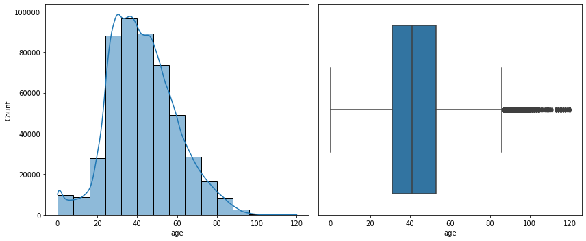

```python
# Olhando a distribuição da variável contínua 'age'
fig, axs = plt.subplots(1,2,figsize=(12,5))

sns.histplot(ax=axs[0], data=df['age'], bins=15, kde=True)
sns.boxplot(ax=axs[1], x=df['age'])

fig.tight_layout();
```

```python
# Verificando as caudas:
print('Menor de 1: ', len(df[df['age']<1]))
print('Maior de 90: ', len(df[df['age']>90]))
```

```
Menor de 1:  2022
Maior de 90:  1422
```

```python
# Calculando correlação entre 'age' (variável contínua) e covid_res (variável binária):
# Devemos usar a point biserial correlation: rpb
from scipy.stats import pointbiserialr
print(pointbiserialr(df_train['covid_res'], df_train['age']))
```

```
PointbiserialrResult(correlation=0.1676982865797974, pvalue=0.0)
```

## 5. Tratamento dos dados

### 5.1 Tratando dados faltantes

```python
# Função preg para tratar os dados ausentes em intubed
def intubed(dfr):
    # Tratando informações faltantes para pacientes dispensados: -1
    dfr.loc[dfr[dfr['patient_type']==1].index,'intubed'] = -1
    # Tratando informações faltantes para pacientes não dispensados: 0
    dfr.loc[dfr[(dfr['patient_type']==0)&(dfr['intubed'].isnull())].index,'intubed'] = 0
```

```python
print('Antes:\n', df_train['intubed'].value_counts())
intubed(df_train)
print('Depois:\n', df_train['intubed'].value_counts())
```

```
Antes:
 0.0    88585
1.0     8180
Name: intubed, dtype: int64
Depois:
 -1.0    352843
 0.0     88700
 1.0      8180
Name: intubed, dtype: int64
```

```python
# Função preg para tratar os dados ausentes em icu
def icu(dfr):
    dfr.loc[dfr[dfr['patient_type']==1].index,'icu'] = -1
    dfr.loc[dfr[(dfr['patient_type']==0)&(dfr['icu'].isnull())].index,'icu'] = 0
```

```python
print('Antes:\n', df_train['icu'].value_counts())
icu(df_train)
print('Depois:\n', df_train['icu'].value_counts())
```

```
Antes:
 0.0    88630
1.0     8134
Name: icu, dtype: int64
Depois:
 -1.0    352843
 0.0     88746
 1.0      8134
Name: icu, dtype: int64
```

```python
# Função preg para tratar os dados ausentes em pregnancy
def pregnant(dfr):
    dfr.loc[dfr[dfr['sex']==0].index,'pregnancy'] = -1
    dfr.loc[dfr[(dfr['sex']==1)&(dfr['pregnancy'].isnull())].index,'pregnancy'] = 0.5
```

```python
print('Antes:\n', df_train['pregnancy'].value_counts())
pregnant(df_train)
print('Depois:\n', df_train['pregnancy'].value_counts())
```

```
Antes:
 0.0    217384
1.0      3250
Name: pregnancy, dtype: int64
Depois:
 -1.0    227882
 0.0    217384
 1.0      3250
 0.5      1207
Name: pregnancy, dtype: int64
```

```python
# Tratando os dados faltantes de pneumonia: 10 casos - NaN para 0
print('Antes:\n', df_train['pneumonia'].value_counts())
df_train['pneumonia'].fillna(value=0,inplace=True)
print('Depois:\n', df_train['pneumonia'].value_counts())
```

```
Antes:
 0.0    378784
1.0     70929
Name: pneumonia, dtype: int64
Depois:
 0.0    378794
1.0     70929
Name: pneumonia, dtype: int64
```

```python
# Tratando os outros dados ausentes usando o imputer do sklearn: substituição de NaN por 0.5
from sklearn.impute import SimpleImputer
imputer = SimpleImputer(missing_values=np.nan, strategy='constant', fill_value=0.5)
```

```python
# Nomes das colunas nas quais utilizar o imputer
cols = ['diabetes', 'copd', 'asthma', 'inmsupr', 'hypertension', 'other_disease',
        'cardiovascular', 'obesity', 'renal_chronic', 'tobacco', 'contact_other_covid']
```

```python
# Aplicação do imputer
df_train.loc[:,cols] = imputer.fit_transform(df_train[cols])
```

```python
# Visualização de dados faltantes:
print(df_train.isnull().sum())
```

```
Unnamed: 0             0
sex                    0
patient_type           0
intubed                0
pneumonia              0
age                    0
pregnancy              0
diabetes               0
copd                   0
asthma                 0
inmsupr                0
hypertension           0
other_disease          0
cardiovascular         0
obesity                0
renal_chronic          0
tobacco                0
contact_other_covid    0
covid_res              0
icu                    0
dtype: int64
```

## 6. Relação das features com a target

No print a seguir, podemos visualizar a relação das features com a target, isto é, a proporção de cada categoria com relação a presença ou ausência de covid.

```python
for item in cat_features:
    print('\nFeature:', item)
    print(df_train.groupby(item)['covid_res'].value_counts(normalize=True))
```

```
Feature: sex
sex  covid_res
0    0            0.522722
     1            0.477278
1    0            0.594940
     1            0.405060
Name: covid_res, dtype: float64

Feature: patient_type
patient_type  covid_res
0             1            0.635322
              0            0.364678
1             0            0.611521
              1            0.388479
Name: covid_res, dtype: float64

Feature: intubed
intubed  covid_res
-1.0     0            0.611521
         1            0.388479
 0.0     1            0.627430
         0            0.372570
 1.0     1            0.720905
         0            0.279095
Name: covid_res, dtype: float64

Feature: pneumonia
pneumonia  covid_res
0.0        0            0.601960
           1            0.398040
1.0        1            0.674576
           0            0.325424
Name: covid_res, dtype: float64

Feature: pregnancy
pregnancy  covid_res
-1.0       0            0.522722
           1            0.477278
 0.0       0            0.595398
           1            0.404602
```

[output cut: 110 more lines]

```
0.5                  1            0.527384
                     0            0.472616
1.0                  0            0.622652
                     1            0.377348
Name: covid_res, dtype: float64

Feature: icu
icu   covid_res
-1.0  0            0.611521
      1            0.388479
 0.0  1            0.634169
      0            0.365831
 1.0  1            0.647898
      0            0.352102
Name: covid_res, dtype: float64
```

## 7. Separando bases de treino e validação

Preparação dos conjuntos de treino e validação

```python
X_for_train = df_train.copy() # Cópia do df_train
X_for_train.drop('Unnamed: 0', axis=1, inplace=True) # Exclusão da coluna 'Unnamed: 0'
X_for_train.head(2)
```

|  | sex | patient_type | intubed | pneumonia | age | pregnancy | diabetes | copd | asthma | inmsupr | hypertension | other_disease | cardiovascular | obesity | renal_chronic | tobacco | contact_other_covid | covid_res | icu |
| --- | --- | --- | --- | --- | --- | --- | --- | --- | --- | --- | --- | --- | --- | --- | --- | --- | --- | --- | --- |
| 497116 | 1 | 0 | 0.0 | 0.0 | 45 | 0.0 | 1.0 | 0.0 | 0.0 | 0.0 | 1.0 | 0.0 | 0.0 | 0.0 | 0.0 | 0.0 | 1.0 | 0 | 0.0 |
| 290587 | 1 | 1 | -1.0 | 0.0 | 23 | 0.0 | 0.0 | 0.0 | 0.0 | 0.0 | 0.0 | 0.0 | 0.0 | 0.0 | 0.0 | 0.0 | 0.5 | 0 | -1.0 |

Iremos agora verificar a presença de dados duplicados no conjunto de dados antes de realizar o treinamento do modelo.

```python
# Tamanho total do conjunto, tamanho do conjunto de dados duplicados, tamanho excluindo duplicados
X_for_train.shape, X_for_train[X_for_train.duplicated()].shape, X_for_train.drop_duplicates().shape
```

```
((449723, 19), (380122, 19), (69601, 19))
```

Considerações:

- Quando retiramos a coluna de identificação dos registros, aparecem muitos casos duplicados - casos em que todas as features e a target são iguais.
- Embora a informação de frequência possa contribuir para captar relações entre features e target, a presença de informações duplicadas entre os conjuntos de treino e validação causará distorções nas métricas. Para evitar isso, a decisão é por retirar os casos duplicados da base que estamos preparando para testar modelos.

```python
# Exclusão dos dados duplicados
X_for_train.drop_duplicates(inplace=True)
X_for_train.shape
```

```
(69601, 19)
```

```python
# Separando um conjunto X (features) e y (target)
X = X_for_train.drop('covid_res',axis=1)
y = X_for_train['covid_res']
X.shape, y.shape
```

```
((69601, 18), (69601,))
```

```python
# Separando conjunto de dados para treino e validação dos modelos
from sklearn.model_selection import train_test_split

X_train, X_valid, y_train, y_valid = train_test_split(X,
                                                    y,
                                                    test_size=0.1,
                                                    random_state=12)
# Verificando o shape dos conjuntos
print(X_train.shape, y_train.shape)
print(X_valid.shape, y_valid.shape)
```

```
(62640, 18) (62640,)
(6961, 18) (6961,)
```

## 8. Modelos

Iremos explorar três modelos de classificação: árvore de decisão, random forest e lightgbm.

### 8.1 Árvore de decisão

Inicialmente utilizamos um modelo de árvore sem especificações, o qual sabemos que irá apresentar overfitting. Isso é feito para termos esse modelo como "baseline".

```python
# Importação de bibliotecas relevantes
from sklearn.tree import DecisionTreeClassifier, plot_tree
# Métricas de avaliação de modelo
from sklearn.metrics import accuracy_score, precision_score, recall_score
```

```python
# Modelo "baseline": árvore de classificação sem especificação de hiperparâmetros
modelo_arvore1 = DecisionTreeClassifier(random_state=15)

# Treino do modelo
modelo_arvore1.fit(X_train, y_train)

# Predições do modelo com os conjuntos de treino e validação
y_train_pred = modelo_arvore1.predict(X_train)

y_valid_pred = modelo_arvore1.predict(X_valid)

# Print de conferência do formato das saídas de predição do treino e validação
print(y_train_pred.shape, y_valid_pred.shape)
```

```
(62640,) (6961,)
```

```python
# Avaliação do modelo
acc_train = accuracy_score(y_train, y_train_pred)
prec_train = precision_score(y_train, y_train_pred)
rec_train = recall_score(y_train, y_train_pred)

acc_valid = accuracy_score(y_valid, y_valid_pred)
prec_valid = precision_score(y_valid, y_valid_pred)
rec_valid = recall_score(y_valid, y_valid_pred)

print(f'Treino:\nAcc: {acc_train:.2f}, Precision: {prec_train:.2f}, Recall: {rec_train:.2f}')
print(f'Validação:\nAcc: {acc_valid:.2f}, Precision: {prec_valid:.2f}, Recall: {rec_valid:.2f}')
```

```
Treino:
Acc: 0.81, Precision: 1.00, Recall: 0.62
Validação:
Acc: 0.33, Precision: 0.32, Recall: 0.29
```

```python
# Verificando a importância das features
importances = pd.DataFrame({
    'feature': X_train.columns,
    'importance': modelo_arvore1.feature_importances_}).sort_values('importance', ascending=False)

importances
```

|  | feature | importance |
| --- | --- | --- |
| 4 | age | 0.439321 |
| 16 | contact_other_covid | 0.089303 |
| 6 | diabetes | 0.065664 |
| 10 | hypertension | 0.061108 |
| 5 | pregnancy | 0.037650 |
| 12 | cardiovascular | 0.032154 |
| 3 | pneumonia | 0.029097 |
| 15 | tobacco | 0.028658 |
| 14 | renal_chronic | 0.028529 |
| 0 | sex | 0.027949 |
| 17 | icu | 0.025912 |
| 13 | obesity | 0.025691 |
| 7 | copd | 0.024863 |
| 8 | asthma | 0.024408 |
| 11 | other_disease | 0.023732 |
| 2 | intubed | 0.019739 |
| 9 | inmsupr | 0.009823 |
| 1 | patient_type | 0.006400 |

**Considerações:**

- Temos um modelo "baseline" com overfit - mais ajustado aos dados de treinamento, sem apresentar boa generalização para o conjunto de validação.
- As features mais importantes nesse modelo de classificação foram 'age' (0.44) e 'contact_other_covid' (0.09), em seguida 'diabetes' (0.066) e 'hypertension' (0.061)

Para diminuir o overfit do modelo, iremos utilizar de GridSearchCV para testar diversas combinações de hiperparâmetros para a árvore de classificação, visando a otimizar a métrica 'recall', isto é, uma medida da capacidade do modelo acertar todos os casos positivos de covid ('covid_res' == 1), ponderando pelos casos em que comete falsos positivos (classificar como 1 quando 'covid_res' == 0). Essa métrica é adequada em vista do nosso objetivo de criar um modelo com capacidade de prever os casos de covid.

### Otimização utilizando GridSearch

```python
# Importação de GridSearchCV
from sklearn.model_selection import GridSearchCV
```

```python
# Criação de um modelo geral para ser utilizado pelo GridSearch
modelo_arvoreCV = DecisionTreeClassifier(random_state=15)

# Especificação dos hiperparâmetros a serem testados
parameters = {
    'criterion':['gini','entropy'], # testa o dois critérios: 'gini' e 'entropy'
    'max_depth': [2, 3, 4, 5],      # testa a profundidade da árvore: 2, 3, 4 e 5
    'min_samples_leaf': [1, 2, 3, 4, 5, 6] # testa diferentes restrições de número de folhas
}

# Executa GridSearch visando a melhora do recall_score
clf = GridSearchCV(modelo_arvoreCV, parameters, verbose=1, scoring='recall')

clf.fit(X_train, y_train)
```

```
Fitting 5 folds for each of 48 candidates, totalling 240 fits
```

```
GridSearchCV(estimator=DecisionTreeClassifier(random_state=15),
             param_grid={'criterion': ['gini', 'entropy'],
                         'max_depth': [2, 3, 4, 5],
                         'min_samples_leaf': [1, 2, 3, 4, 5, 6]},
             scoring='recall', verbose=1)
```

```python
# Verificando os melhores parâmetros obtidos com o GridSearch
clf.best_params_
```

```
{'criterion': 'entropy', 'max_depth': 4, 'min_samples_leaf': 4}
```

```python
# Especificando um modelo com os melhores parâmetros obtidos
modelo_arvore2 = DecisionTreeClassifier(criterion='entropy',max_depth=4, min_samples_leaf=4, random_state=15)

# Treino do modelo
modelo_arvore2.fit(X_train, y_train)

# Predições do modelo
y_train_pred = modelo_arvore2.predict(X_train)

y_valid_pred = modelo_arvore2.predict(X_valid)

print(y_train_pred.shape, y_valid_pred.shape)
```

```
(62640,) (6961,)
```

```python
# Métricas de avaliação do modelo
acc_train = accuracy_score(y_train, y_train_pred)
prec_train = precision_score(y_train, y_train_pred)
rec_train = recall_score(y_train, y_train_pred)

acc_valid = accuracy_score(y_valid, y_valid_pred)
prec_valid = precision_score(y_valid, y_valid_pred)
rec_valid = recall_score(y_valid, y_valid_pred)

print(f'Treino:\nAcc: {acc_train:.2f}, Precision: {prec_train:.2f}, Recall: {rec_train:.2f}')
print(f'Validação:\nAcc: {acc_valid:.2f}, Precision: {prec_valid:.2f}, Recall: {rec_valid:.2f}')
```

```
Treino:
Acc: 0.58, Precision: 0.58, Recall: 0.63
Validação:
Acc: 0.57, Precision: 0.57, Recall: 0.62
```

```python
# Verificando a importância das features
importances = pd.DataFrame({
    'feature': X_train.columns,
    'importance': modelo_arvore2.feature_importances_}).sort_values('importance', ascending=False)

importances
```

|  | feature | importance |
| --- | --- | --- |
| 3 | pneumonia | 0.449799 |
| 4 | age | 0.249356 |
| 2 | intubed | 0.159433 |
| 13 | obesity | 0.068104 |
| 9 | inmsupr | 0.056825 |
| 11 | other_disease | 0.012253 |
| 12 | cardiovascular | 0.004230 |
| 16 | contact_other_covid | 0.000000 |
| 15 | tobacco | 0.000000 |
| 14 | renal_chronic | 0.000000 |
| 0 | sex | 0.000000 |
| 10 | hypertension | 0.000000 |
| 1 | patient_type | 0.000000 |
| 8 | asthma | 0.000000 |
| 7 | copd | 0.000000 |
| 6 | diabetes | 0.000000 |
| 5 | pregnancy | 0.000000 |
| 17 | icu | 0.000000 |

As features mais importantes foram 'pneumonia' (0.45), 'age' (0.25), 'intubed' (0.16), 'obesity' (0.07), 'inmsupr' (0.06).

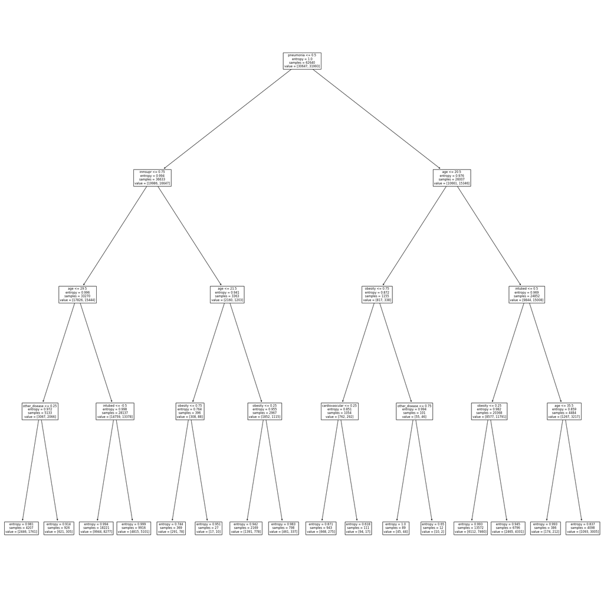

```python
# Visualizando a árvore: melhor visualizada se abrir como imagem em nova aba e 100% de zoom
plt.figure(figsize=(30, 30))
plot_tree(modelo_arvore2, feature_names=X_train.columns)
plt.show()
```

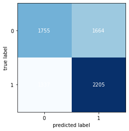

```python
# Visualizando a matriz de confusão
from mlxtend.plotting import plot_confusion_matrix
from sklearn.metrics import confusion_matrix

cm = confusion_matrix(y_valid, y_valid_pred)

plot_confusion_matrix(conf_mat=cm)
plt.show()
```

**Considerações:**

- Através do GridSearch, obtivemos uma árvore de decisão que não apresenta overfit e que funciona segundo variáveis que sabemos ser relevantes para os casos de covid e hospitalização, a saber, a presença de um quadro de pneumonia, a idade, a ocorrência de intubação e a obesidade.

A seguir, iremos verificar se um modelo tipo random forest é superior ao obtido com uma única árvore de decisão. Iremos testar algumas configurações de hiperparâmetros através de GridSearch com o intuito de melhorar a métrica recall_score.

### 8.2 Random forest

```python
from sklearn.ensemble import RandomForestClassifier
```

```python
# Criando um modelo de random forest para ser otimizado usando GridSearch
modelo_randomForestCV = RandomForestClassifier(random_state=12)

# Parâmetros a serem testados
parameters = {
    'n_estimators':[50, 100, 150],
    'criterion':['gini','entropy'],
    'max_depth': [2, 3, 4],
    'min_samples_leaf': [1, 2, 3]
}

# GridSearch com o objetivo de melhorar o recall_score
clf = GridSearchCV(modelo_randomForestCV, parameters, verbose=1, scoring='recall')

clf.fit(X_train, y_train)
```

```
Fitting 5 folds for each of 54 candidates, totalling 270 fits
```

```
GridSearchCV(estimator=RandomForestClassifier(random_state=12),
             param_grid={'criterion': ['gini', 'entropy'],
                         'max_depth': [2, 3, 4], 'min_samples_leaf': [1, 2, 3],
                         'n_estimators': [50, 100, 150]},
             scoring='recall', verbose=1)
```

```python
# Visualizando os melhores hiperparâmetros
clf.best_params_
```

```
{'criterion': 'gini',
 'max_depth': 2,
 'min_samples_leaf': 1,
 'n_estimators': 100}
```

```python
# Implementação do melhor modelo dado pelo GridSearch
modelo_randomForest = RandomForestClassifier(n_estimators=100, criterion='gini',
                                             max_depth=2, min_samples_leaf=1,
                                             random_state=12)

# Treino do modelo
modelo_randomForest.fit(X_train, y_train)

# Preditos do modelo
y_train_pred = modelo_randomForest.predict(X_train)

y_valid_pred = modelo_randomForest.predict(X_valid)

print(y_train_pred.shape, y_valid_pred.shape)
```

```
(62640,) (6961,)
```

```python
# Métricas do modelo
acc_train = accuracy_score(y_train, y_train_pred)
prec_train = precision_score(y_train, y_train_pred)
rec_train = recall_score(y_train, y_train_pred)

acc_valid = accuracy_score(y_valid, y_valid_pred)
prec_valid = precision_score(y_valid, y_valid_pred)
rec_valid = recall_score(y_valid, y_valid_pred)

print(f'Treino:\nAcc: {acc_train:.2f}, Precision: {prec_train:.2f}, Recall: {rec_train:.2f}')
print(f'Validação:\nAcc: {acc_valid:.2f}, Precision: {prec_valid:.2f}, Recall: {rec_valid:.2f}')
```

```
Treino:
Acc: 0.58, Precision: 0.58, Recall: 0.61
Validação:
Acc: 0.57, Precision: 0.57, Recall: 0.61
```

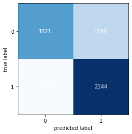

```python
# Visualização da matriz de confusão
cm = confusion_matrix(y_valid, y_valid_pred)

plot_confusion_matrix(conf_mat=cm)
plt.show()
```

**Considerações:**

- A random Forest teve desempenho um pouco inferior ao da árvore de decisão
- modelo_arvore2:  
  Treino: Acc: 0.58, Precision: 0.58, Recall: 0.63  
  Validação: Acc: 0.57, Precision: 0.57, Recall: 0.62

A seguir, iremos testar se um classificador lightgbm é capaz de superar o desempenho da árvore de classificação.

### 8.3 Lightgbm

```python
from lightgbm import LGBMClassifier
```

```python
# Criando um modelo lightgbm para ser otimizado usando GridSearch
modelo_lightgbm = LGBMClassifier(random_state=25)

# Parâmetros a serem testados
parameters = {
    'max_depth': [2, 3, 4, 5],
    'n_estimators': [40, 70, 100],
    'learning_rate': [0.01, 0.1]
}

# GridSearch com o objetivo de otimizar o recall_score
clf = GridSearchCV(modelo_lightgbm, parameters, verbose=1, scoring='recall')

clf.fit(X_train, y_train)
```

```
Fitting 5 folds for each of 24 candidates, totalling 120 fits
```

```
GridSearchCV(estimator=LGBMClassifier(random_state=25),
             param_grid={'learning_rate': [0.01, 0.1],
                         'max_depth': [2, 3, 4, 5],
                         'n_estimators': [40, 70, 100]},
             scoring='recall', verbose=1)
```

```python
# Melhores parâmetros testados pelo GridSearch
clf.best_params_
```

```
{'learning_rate': 0.01, 'max_depth': 4, 'n_estimators': 40}
```

```python
# Implementação do melhor modelo dado pelo GridSearch
modelo_lightgbm = LGBMClassifier(n_estimators=40, max_depth=4, learning_rate=0.01, random_state=25)

# Treino do modelo
modelo_lightgbm.fit(X_train, y_train)

# Preditos do modelo
y_train_pred = modelo_lightgbm.predict(X_train)

y_valid_pred = modelo_lightgbm.predict(X_valid)

print(y_train_pred.shape, y_valid_pred.shape)
```

```
(62640,) (6961,)
```

```python
acc_train = accuracy_score(y_train, y_train_pred)
prec_train = precision_score(y_train, y_train_pred)
rec_train = recall_score(y_train, y_train_pred)

acc_valid = accuracy_score(y_valid, y_valid_pred)
prec_valid = precision_score(y_valid, y_valid_pred)
rec_valid = recall_score(y_valid, y_valid_pred)

print(f'Treino:\nAcc: {acc_train:.2f}, Precision: {prec_train:.2f}, Recall: {rec_train:.2f}')
print(f'Validação:\nAcc: {acc_valid:.2f}, Precision: {prec_valid:.2f}, Recall: {rec_valid:.2f}')
```

```
Treino:
Acc: 0.58, Precision: 0.58, Recall: 0.63
Validação:
Acc: 0.57, Precision: 0.57, Recall: 0.62
```

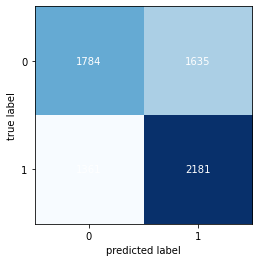

```python
# Visualização da matriz de confusão
cm = confusion_matrix(y_valid, y_valid_pred)

plot_confusion_matrix(conf_mat=cm)
plt.show()
```

**Considerações:**

- O modelo lightgbm atingiu o mesmo nível de desempenho da árvore de decisão (modelo_arvore2).
- Podemos ficar com o modelo de árvore de decisão, de funcionamento e implementação mais simples.

### 8.4 Otimizando o modelo escolhido

Aqui, iremos explorar se é possível melhorar o desempenho do modelo a partir das predições probabilísticas do modelo, selecionando algum ponto de corte que permita melhor classificar os casos de covid.

```python
# Criando uma função para pegar as predições de acordo com diversos pontos de corte
# Essa função recebe probabilidades preditas e um ponto de corte, aplica uma máscara
# e converte as probabilidades em valores binários com base no ponto de corte
def get_prediction(y_pred_prob, corte):
    y_pred_prob = y_pred_prob.copy()
    mask = (y_pred_prob >= corte)
    y_pred_prob[mask] = 1 # probabilidades maiores ou iguais à de corte são 1
    y_pred_prob[~mask] = 0

    return y_pred_prob
```

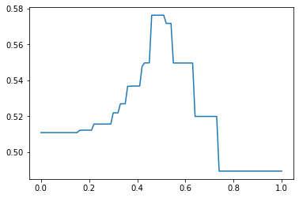

```python
# Pega-se as probabilidades a partir do conjunto de treino
y_pred_train_proba = modelo_arvore2.predict_proba(X_train)[:,1]

# Listas vazias para armezar acurácias e pontos de corte
acuracias = []
cortes = []

# Para cada ponto de corte entre 0 e 1 (em passos de 0.1)
for corte in np.linspace(0, 1, 101):

    # Verificamos a acurácia para o ponto de corte definido
    acc_train = accuracy_score(y_train, get_prediction(y_pred_train_proba, corte=corte))

    # Adicionamos os valores na respectiva lista
    acuracias.append(acc_train)
    cortes.append(corte)

# Gráfico
plt.plot(cortes, acuracias);
```

```python
# Encotrando o ponto de maior acurácia
acuracia_maxima = np.max(acuracias)

melhor_corte = cortes[acuracias.index(acuracia_maxima)]

print(f'O melhor ponto de corte é em {melhor_corte}')
```

[output not shown]

No modelo aqui proposto, o ponto de corte é centrado em 0.5 (50%) e não ocorre ganho do funcionamento do modelo.

```python
# Comparando treino e validação com base no melhor ponto de corte
y_train_pred = get_prediction(modelo_arvore2.predict_proba(X_train)[:,1], corte=melhor_corte)

y_valid_pred = get_prediction(modelo_arvore2.predict_proba(X_valid)[:,1], corte=melhor_corte)

print(y_train_pred.shape, y_valid_pred.shape)

acc_train = accuracy_score(y_train, y_train_pred)
prec_train = precision_score(y_train, y_train_pred)
rec_train = recall_score(y_train, y_train_pred)

acc_valid = accuracy_score(y_valid, y_valid_pred)
prec_valid = precision_score(y_valid, y_valid_pred)
rec_valid = recall_score(y_valid, y_valid_pred)

print(f'Treino:\nAcc: {acc_train:.10f}, Precision: {prec_train:.10f}, Recall: {rec_train:.10f}')
print(f'Validação:\nAcc: {acc_valid:.10f}, Precision: {prec_valid:.10f}, Recall: {rec_valid:.10f}')
```

```
(62640,) (6961,)
Treino:
Acc: 0.5762611750, Precision: 0.5783766682, Recall: 0.6285437439
Validação:
Acc: 0.5688837811, Precision: 0.5699147066, Recall: 0.6225296443
```

**Considerações:**

- O melhor modelo ajustado é a árvore de decisão criada com os seguintes hiperparâmetros:  
  DecisionTreeClassifier(criterion='entropy',max_depth=4, min_samples_leaf=4, random_state=15)
- Podemos utilizar esse parâmetro com os dados de teste - um subconjunto aleatório separado da base original. Dessa maneira, verificamos o funcionamento do modelo em um contexto "realístico".

## 9. Teste final do modelo

### 9.1 Carregando e tratando os dados

```python
# Visualização do conjunto de teste
df_test.head(3)
```

|  | Unnamed: 0 | sex | patient_type | intubed | pneumonia | age | pregnancy | diabetes | copd | asthma | inmsupr | hypertension | other_disease | cardiovascular | obesity | renal_chronic | tobacco | contact_other_covid | covid_res | icu |
| --- | --- | --- | --- | --- | --- | --- | --- | --- | --- | --- | --- | --- | --- | --- | --- | --- | --- | --- | --- | --- |
| 0 | 0 | 0 | 1 | NaN | 0.0 | 27 | NaN | 0.0 | 0.0 | 0.0 | 0.0 | 0.0 | 0.0 | 0.0 | 0.0 | 0.0 | 0.0 | 0.0 | 1 | NaN |
| 38 | 38 | 0 | 1 | NaN | 0.0 | 32 | NaN | 0.0 | 0.0 | 0.0 | 0.0 | 0.0 | 0.0 | 0.0 | 0.0 | 0.0 | 0.0 | NaN | 1 | NaN |
| 39 | 39 | 0 | 1 | NaN | 1.0 | 56 | NaN | 0.0 | 0.0 | 0.0 | 0.0 | 0.0 | 0.0 | 0.0 | 0.0 | 0.0 | 0.0 | 0.0 | 1 | NaN |

```python
# Cópia do conjunto de teste
X_test = df_test.copy()
```

```python
# Exclusão da coluna 'Unnamed: 0'
X_test.drop('Unnamed: 0',axis=1,inplace=True)
```

```python
# Contagem de valores faltantes em cada coluna
print(X_test.isnull().sum())
```

```
sex                        0
patient_type               0
intubed                39310
pneumonia                  1
age                        0
pregnancy              25345
diabetes                 171
copd                     160
asthma                   156
inmsupr                  180
hypertension             165
other_disease            235
cardiovascular           168
obesity                  152
renal_chronic            161
tobacco                  173
contact_other_covid    15273
covid_res                  0
icu                    39310
dtype: int64
```

Tratamento dos dados faltantes seguindo os mesmos procedimentos do conjunto de treino:

```python
print('Antes:\n', X_test['intubed'].value_counts())
intubed(X_test)
print('Depois:\n', X_test['intubed'].value_counts())
```

```
Antes:
 0.0    9736
1.0     923
Name: intubed, dtype: int64
Depois:
 -1.0    39303
 0.0     9743
 1.0      923
Name: intubed, dtype: int64
```

```python
print('Antes:\n', X_test['icu'].value_counts())
icu(X_test)
print('Depois:\n', X_test['icu'].value_counts())
```

```
Antes:
 0.0    9784
1.0     875
Name: icu, dtype: int64
Depois:
 -1.0    39303
 0.0     9791
 1.0      875
Name: icu, dtype: int64
```

```python
print('Antes:\n', X_test['pregnancy'].value_counts())
pregnant(X_test)
print('Depois\n', X_test['pregnancy'].value_counts())
```

```
Antes:
 0.0    24260
1.0      364
Name: pregnancy, dtype: int64
Depois
 -1.0    25216
 0.0    24260
 1.0      364
 0.5      129
Name: pregnancy, dtype: int64
```

```python
# Tratando os dados faltantes de pneumonia: 10 casos - NaN para 0
print('Antes:\n', X_test['pneumonia'].value_counts())
X_test['pneumonia'].fillna(value=0,inplace=True)
print('Depois:\n', X_test['pneumonia'].value_counts())
```

```
Antes:
 0.0    42181
1.0     7787
Name: pneumonia, dtype: int64
Depois:
 0.0    42182
1.0     7787
Name: pneumonia, dtype: int64
```

```python
# Aplicação do imputer
X_test.loc[:,cols] = imputer.fit_transform(X_test[cols])
```

```python
# Visualização de dados faltantes:
print(X_test.isnull().sum())
```

```
sex                    0
patient_type           0
intubed                0
pneumonia              0
age                    0
pregnancy              0
diabetes               0
copd                   0
asthma                 0
inmsupr                0
hypertension           0
other_disease          0
cardiovascular         0
obesity                0
renal_chronic          0
tobacco                0
contact_other_covid    0
covid_res              0
icu                    0
dtype: int64
```

```python
# Há dados duplicados no conjunto de teste?
X_test.shape, X_test.drop_duplicates().shape
```

```
((49969, 19), (16349, 19))
```

### 9.2 Implementando o teste do modelo

```python
# Remoção dos casos duplicados para não distorcer métricas
X_test.drop_duplicates(inplace=True)
# Separação da target (Obs: esqueci de chamar de "y_test" !)
y = X_test['covid_res']
# Remove a target do conjunto de features
X_test.drop('covid_res',axis=1, inplace=True)
```

```python
print(X_test.shape, y.shape)
```

```
(16349, 18) (16349,)
```

```python
# Aplica os dados de teste no modelo:
y_train_pred = modelo_arvore2.predict(X_train)

y_test_pred = modelo_arvore2.predict(X_test)

print(y_train_pred.shape, y_test_pred.shape)
```

```
(62640,) (16349,)
```

#### Comparando treino e teste

```python
# Métricas de avaliação do modelo
acc_train = accuracy_score(y_train, y_train_pred)
prec_train = precision_score(y_train, y_train_pred)
rec_train = recall_score(y_train, y_train_pred)

acc_test = accuracy_score(y, y_test_pred)
prec_test = precision_score(y, y_test_pred)
rec_test = recall_score(y, y_test_pred)

print(f'Treino:\nAcc: {acc_train:.2f}, Precision: {prec_train:.2f}, Recall: {rec_train:.2f}')
print(f'Teste:\nAcc: {acc_test:.2f}, Precision: {prec_test:.2f}, Recall: {rec_test:.2f}')
```

```
Treino:
Acc: 0.58, Precision: 0.58, Recall: 0.63
Teste:
Acc: 0.59, Precision: 0.62, Recall: 0.55
```

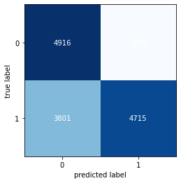

```python
# Plot da matriz de confusão
cm = confusion_matrix(y, y_test_pred)

plot_confusion_matrix(conf_mat=cm)
plt.show()
```

**Considerações finais:**

- O teste do modelo em contexto realístico apresentou boa acurácia e precisão com relação ao seu treinamento, mas o desempenho foi inferior em termos de recall, isto é, o modelo apresentou muitos falsos negativos, embora apresente boa capacidade de prever os casos positivos e negativos.